# **建行实习-ML项目**

# 目录

- 设置环境和packages

  ### 一、读取数据和数据结构分析

  ```
   - 1. 缺失值查看
  ```

  ### 二、特征分析

  ```
   - 1.Status相关性
   - 2.各变量在Status不同值下的差异
   - 3.所有变量相关性分析
  ```

  ### 三、特征处理：缺失值填补+归一化

  ```
   - 1.归一化
   - 2.分类变量标签编码
  ```

  ### 四、模型训练

  ```
   - 1.随机森林模型
   - 2.逻辑回归模型
   - 3.梯度提升决策树模型 (LGBM)
   - 4.模型结果比较
  ```

  ### 五、结果分析

# 设置环境和packages

```python
# numpy and pandas for data manipulation
import numpy as np
import pandas as pd

# sklearn preprocessing for dealing with categorical variables
from sklearn.preprocessing import LabelEncoder
from sklearn.model_selection import train_test_split
from sklearn.model_selection import StratifiedKFold
from lightgbm import LGBMClassifier
from sklearn.experimental import enable_iterative_imputer
from sklearn.impute import IterativeImputer
from sklearn.metrics import accuracy_score, precision_score, roc_auc_score, recall_score
from sklearn.ensemble import RandomForestClassifier
from sklearn.linear_model import LogisticRegression
from sklearn.preprocessing import MinMaxScaler

# File system manangement
import os

# Suppress warnings
import warnings
warnings.filterwarnings('ignore')
warnings.filterwarnings("ignore", message="Found whitespace in feature_names")

# matplotlib and seaborn for plotting
import matplotlib.pyplot as plt
import seaborn as sns

#模型调优
from sklearn.model_selection import GridSearchCV

# 优雅地模板打印
from tabulate import tabulate
```

```python
# set full displayable
pd.set_option('display.max_columns',None)
```

# 一、读取数据和数据结构分析

```python
# readin the data
data = pd.read_csv("risk_lable_train.csv")
```

```python
# 数据概略
data.head()
```

|  | ID | year | loan_limit | Gender | approv_in_adv | loan_type | loan_purpose | Credit_Worthiness | open_credit | business_or_commercial | loan_amount | rate_of_interest | Interest_rate_spread | Upfront_charges | term | Neg_ammortization | interest_only | lump_sum_payment | property_value | construction_type | occupancy_type | Secured_by | total_units | income | credit_type | Credit_Score | co-applicant_credit_type | age | submission_of_application | … |
| --- | --- | --- | --- | --- | --- | --- | --- | --- | --- | --- | --- | --- | --- | --- | --- | --- | --- | --- | --- | --- | --- | --- | --- | --- | --- | --- | --- | --- | --- | --- |
| 0 | 24890 | 2019 | cf | Sex Not Available | nopre | type1 | p1 | l1 | nopc | nob/c | 116500 | NaN | NaN | NaN | 360.0 | not_neg | not_int | not_lpsm | 118000.0 | sb | pr | home | 1U | 1740.0 | EXP | 758 | CIB | 25-34 | to_inst | … |
| 1 | 24891 | 2019 | cf | Male | nopre | type2 | p1 | l1 | nopc | b/c | 206500 | NaN | NaN | NaN | 360.0 | not_neg | not_int | lpsm | NaN | sb | pr | home | 1U | 4980.0 | EQUI | 552 | EXP | 55-64 | to_inst | … |
| 2 | 24892 | 2019 | cf | Male | pre | type1 | p1 | l1 | nopc | nob/c | 406500 | 4.56 | 0.2000 | 595.0 | 360.0 | neg_amm | not_int | not_lpsm | 508000.0 | sb | pr | home | 1U | 9480.0 | EXP | 834 | CIB | 35-44 | to_inst | … |
| 3 | 24893 | 2019 | cf | Male | nopre | type1 | p4 | l1 | nopc | nob/c | 456500 | 4.25 | 0.6810 | NaN | 360.0 | not_neg | not_int | not_lpsm | 658000.0 | sb | pr | home | 1U | 11880.0 | EXP | 587 | CIB | 45-54 | not_inst | … |
| 4 | 24894 | 2019 | cf | Joint | pre | type1 | p1 | l1 | nopc | nob/c | 696500 | 4.00 | 0.3042 | 0.0 | 360.0 | not_neg | not_int | not_lpsm | 758000.0 | sb | pr | home | 1U | 10440.0 | CRIF | 602 | EXP | 25-34 | not_inst | … |

```python
#根据实际意义将Status列类型改为类别型数据
data['Status'] = data['Status'].astype('object')
data.dtypes.value_counts()
```

```
object     22
float64     8
int64       4
dtype: int64
```

```python
#分类变量的类别数
data[data.dtypes.index[data.dtypes.values=='object']].apply(pd.Series.nunique,axis=0) #None不算类别
```

```
loan_limit                   2
Gender                       4
approv_in_adv                2
loan_type                    3
loan_purpose                 4
Credit_Worthiness            2
open_credit                  2
business_or_commercial       2
Neg_ammortization            2
interest_only                2
lump_sum_payment             2
construction_type            2
occupancy_type               3
Secured_by                   2
total_units                  4
credit_type                  4
co-applicant_credit_type     2
age                          7
submission_of_application    2
Region                       4
Security_Type                2
Status                       2
dtype: int64
```

## 1.缺失值查看

```python
# Function to calculate missing values by column# Funct
def missing_values_table(df0,df1):
        # 总缺失数
        mis0_val = df0.isnull().sum()#标签为0时数据缺失
        mis1_val = df1.isnull().sum()#标签为1时数据缺失

        # 缺失占比
        mis0_val_percent = 100 * df0.isnull().sum() / len(df0)
        mis1_val_percent = 100 * df1.isnull().sum() / len(df1)

        # 聚合列形成表格
        mis_val_table = pd.concat([mis0_val, mis0_val_percent,
                                   mis1_val, mis1_val_percent],
                                  axis=1)#按列聚合计算结果

        # 重命名列
        mis_val_table_ren_columns = mis_val_table.rename(
        columns = {0 : '0标签缺失数', 1 : '% 0标签缺失占比',2:'1标签缺失数',3:'% 1标签缺失占比'})

        # 通过标签1列的缺失值降序排列
        mis_val_table_ren_columns = mis_val_table_ren_columns[mis_val_table_ren_columns['1标签缺失数']!=0].sort_values(
        '1标签缺失数', ascending=False).round(2)

        # 打印总结情况
        print ("数据集有"+str(df0.shape[1])+"列\n"+
               "标签为0的数据集中有 " + str(mis0_val[mis0_val != 0].index.shape[0]) + " 列有空值.\n" +
               "标签为1的数据集中有 " + str(mis1_val[mis1_val != 0].index.shape[0]) + " 列有空值.\n" )

        # Return the dataframe with missing information
        return mis_val_table_ren_columns
```

```python
# 缺失值情况
missing_values = missing_values_table(data[data['Status']==0],
                                      data[data['Status']==1])
missing_values.head(20)
```

```
数据集有34列
标签为0的数据集中有 8 列有空值.
标签为1的数据集中有 14 列有空值.
```

|  | 0标签缺失数 | % 0标签缺失占比 | 1标签缺失数 | % 1标签缺失占比 |
| --- | --- | --- | --- | --- |
| Interest_rate_spread | 0 | 0.00 | 24557 | 100.00 |
| Upfront_charges | 2116 | 2.80 | 24456 | 99.59 |
| rate_of_interest | 0 | 0.00 | 24421 | 99.45 |
| dtir1 | 5201 | 6.89 | 10907 | 44.42 |
| property_value | 0 | 0.00 | 10095 | 41.11 |
| LTV | 0 | 0.00 | 10095 | 41.11 |
| income | 5266 | 6.98 | 832 | 3.39 |
| loan_limit | 1674 | 2.22 | 586 | 2.39 |
| approv_in_adv | 462 | 0.61 | 157 | 0.64 |
| age | 0 | 0.00 | 136 | 0.55 |
| submission_of_application | 0 | 0.00 | 136 | 0.55 |
| loan_purpose | 67 | 0.09 | 19 | 0.08 |
| Neg_ammortization | 54 | 0.07 | 18 | 0.07 |
| term | 20 | 0.03 | 12 | 0.05 |

- 标签1数据集中的变量Interest_rate_spread,Upfront_charges,rate_of_interest缺失值占比极高，有明显勾稽关系，无有效数据
- 缺失值处理在后续有详细说明

# 二、特征分析

尝试手动编码

```python
traindfdrop = data.drop(['ID','year','rate_of_interest','Interest_rate_spread','Upfront_charges'],axis = 1)#去除无效变量
traindfcom = data.drop(['ID','year'],axis = 1)#不去除缺失值占比较大的不删除
```

```python
#分类变量编码
traindfdrop['loan_limit'] = traindfdrop['loan_limit'].map({'cf':1,'ncf':0})
traindfdrop['approv_in_adv'] = traindfdrop['approv_in_adv'].map({'pre':1,'nopre':0})
traindfdrop['Credit_Worthiness'] = traindfdrop['Credit_Worthiness'].map({'l2':1,'l1':0})
traindfdrop['open_credit'] = traindfdrop['open_credit'].map({'opc':1,'nopc':0})
traindfdrop['business_or_commercial'] = traindfdrop['business_or_commercial'].map({'b/c':1,'nob/c':0})
traindfdrop['Neg_ammortization'] = traindfdrop['Neg_ammortization'].map({'neg_amm':1,'not_neg':0})
traindfdrop['interest_only'] = traindfdrop['interest_only'].map({'int_only':1,'not_int':0})
traindfdrop['lump_sum_payment'] = traindfdrop['lump_sum_payment'].map({'lpsm':1,'not_lpsm':0})
traindfdrop['construction_type'] = traindfdrop['construction_type'].map({'mh':1,'sb':0})
traindfdrop['Secured_by'] = traindfdrop['Secured_by'].map({'land':1,'home':0})
traindfdrop['co-applicant_credit_type'] = traindfdrop['co-applicant_credit_type'].map({'CIB':1,'EXP':0})
traindfdrop['submission_of_application'] = traindfdrop['submission_of_application'].map({'to_inst':1,'not_inst':0})
traindfdrop['Security_Type'] = traindfdrop['Security_Type'].map({'direct':1,'Indriect':0})
traindfdrop['Status'] = traindfdrop['Status'].map({1:1,0:0})
encoded_df = pd.get_dummies(traindfdrop)
```

### 数值型变量统计量

```python
#数值型变量描述性统计量
encoded_df[['loan_amount','term','property_value','income','Credit_Score','LTV','dtir1']].describe()
```

|  | loan_amount | term | property_value | income | Credit_Score | LTV | dtir1 |
| --- | --- | --- | --- | --- | --- | --- | --- |
| count | 9.999900e+04 | 99967.000000 | 8.990400e+04 | 93901.000000 | 99999.000000 | 89904.000000 | 83891.000000 |
| mean | 3.309711e+05 | 335.208709 | 4.972403e+05 | 6947.724731 | 699.722227 | 72.907028 | 37.792195 |
| std | 1.840057e+05 | 58.329561 | 3.614757e+05 | 6585.115614 | 115.914034 | 46.262069 | 10.503695 |
| min | 2.650000e+04 | 96.000000 | 8.000000e+03 | 0.000000 | 500.000000 | 0.967478 | 5.000000 |
| 25% | 1.965000e+05 | 360.000000 | 2.680000e+05 | 3720.000000 | 599.000000 | 60.551948 | 31.000000 |
| 50% | 2.965000e+05 | 360.000000 | 4.180000e+05 | 5700.000000 | 699.000000 | 75.173611 | 39.000000 |
| 75% | 4.365000e+05 | 360.000000 | 6.180000e+05 | 8520.000000 | 800.000000 | 86.371237 | 45.000000 |
| max | 3.576500e+06 | 360.000000 | 1.650800e+07 | 578580.000000 | 900.000000 | 7831.250000 | 61.000000 |

- 有异常值但符合实际意义，不做处理

## 1.Status相关性

```python
correlations = encoded_df.corr()['Status'].sort_values()
print('最强正相关变量:\n', correlations.tail(8))
print('\n最强负相关变量:\n', correlations.head(8))
```

```
最强正相关变量:
 dtir1                        0.076444
business_or_commercial       0.090545
loan_type_type2              0.090545
submission_of_application    0.119186
Neg_ammortization            0.160580
lump_sum_payment             0.185245
credit_type_EQUI             0.591709
Status                       1.000000
Name: Status, dtype: float64

最强负相关变量:
 co-applicant_credit_type   -0.144517
credit_type_CIB            -0.141774
credit_type_CRIF           -0.125179
credit_type_EXP            -0.124674
loan_type_type1            -0.077858
Gender_Joint               -0.077489
income                     -0.061559
loan_limit                 -0.057503
Name: Status, dtype: float64
```

- 由于绝大多数变量与Status的线性相关系数小于20%，可以得出变量与结果status呈现弱线性相关性

## 2.各变量在Status不同值下的差异

### 数值型变量差异分析

- 对非肥尾变量

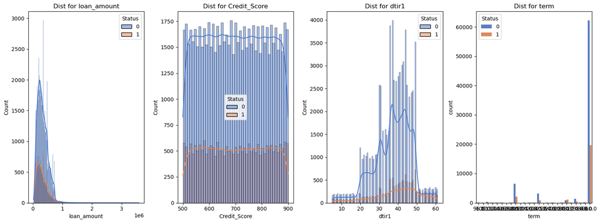

```python
# 数值变量Status分布差异
numerical_col1 = ['loan_amount', 'Credit_Score', 'dtir1']
fig, axes = plt.subplots(nrows=1, ncols=4, figsize=(16, 6))
for i, column in enumerate(numerical_col1):
    title = 'Dist for {}'.format(column)
    sns.histplot(data=encoded_df, x=column, hue='Status', kde=True, ax=axes[i], palette='muted')
    axes[i].set_title(title)
sns.countplot(data=encoded_df, x='term', hue='Status', ax=axes[3], palette='muted')
axes[3].set_title('Dist for term')
# 调整子图之间的间距
plt.tight_layout()

# 显示图形
plt.show()
```

- 对肥尾变量

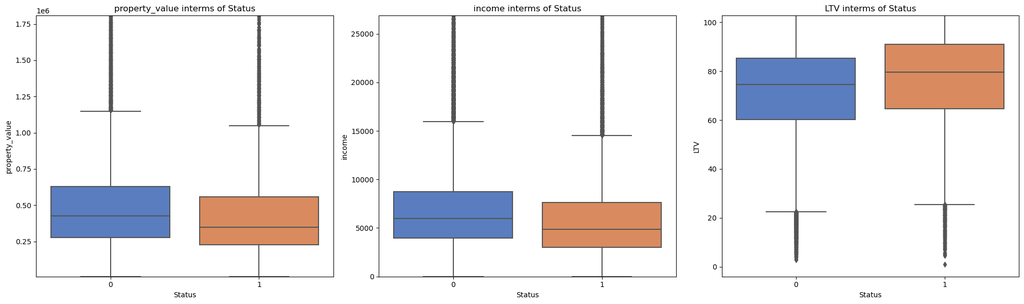

```python
# 长尾型数值变量Status差异
numerical_col2 = ['property_value', 'income', 'LTV']
import numpy as np
# 创建一个小提琴图
fig, axes = plt.subplots(nrows=1, ncols=3, figsize=(20, 6))
for i, column in enumerate(numerical_col2):
    title = '{} interms of Status'.format(column)
    sns.boxplot(x='Status', y=column, data=encoded_df, palette='muted', ax=axes[i])
    axes[i].set_title(title)

    # 设置 y 轴的限制，只显示四分位数部分
    data_without_nan = encoded_df[column].dropna()
    axes[i].set_ylim(ymin=min(data_without_nan)-5, ymax=np.quantile(data_without_nan, 0.99))

# 调整子图之间的间距
plt.tight_layout()

# 显示图形
plt.show()
```

### 分类变量差异

```python
def plot_countplot_with_binary_comparison(df, category_columns, binary_column):
    """
    绘制所有分类变量的柱状图，并使用Status变量对比。

    参数：
    df: DataFrame，输入的数据框。
    category_columns: list，包含所有分类变量的列名列表。
    binary_column: str，用于对比的二分类变量的列名。

    返回：
    无返回值，直接绘制图形。
    """
    num_plots = len(category_columns)
    num_rows = 2
    num_cols = 3
    # 设置图形大小
    plt.figure(figsize=(15, 12))

    # 绘制所有分类变量的箱线图
    for idx, column in enumerate(category_columns, 1):
        plt.subplot(num_rows, num_cols, idx)
        sns.countplot(x=column,hue=binary_column, data=df,palette='pastel')
        plt.title(f'{column}类别在{binary_column}下的差异')
        plt.xlabel(column)
        plt.ylabel(binary_column)

    # 显示图形
    plt.tight_layout()
    plt.show()
```

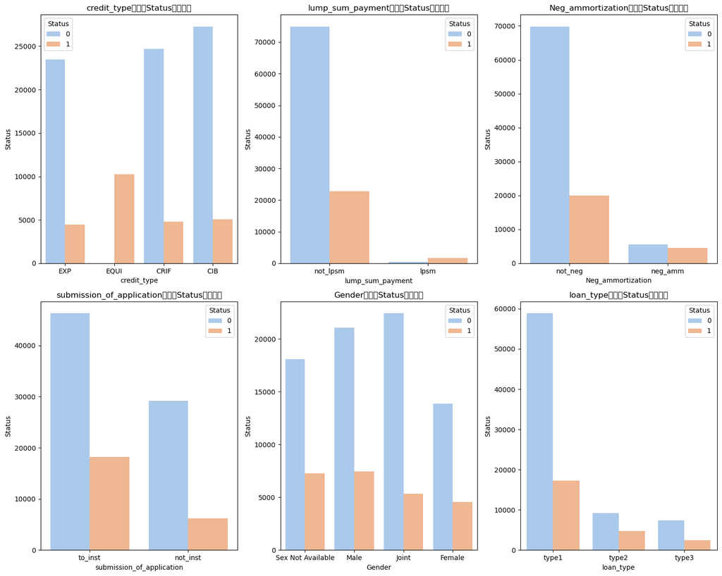

```python
category_columns = ['credit_type','lump_sum_payment','Neg_ammortization','submission_of_application','Gender','loan_type',]
plot_countplot_with_binary_comparison(data,category_columns,'Status')
```

- EQUI的标签情况异常，需要了解变量的具体意义
- 以下变量的分类有较明显的差异:
  - lum_sum_payment: lpsm
  - Neg_ammortization: reg_anm
  - sex not avaliable
  - loan_type: type2 and type3

## 3.所有变量相关性分析

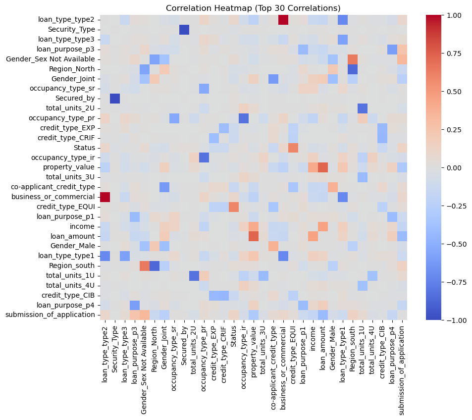

```
Top 30 Correlations:
business_or_commercial - loan_type_type2: 1.0000
Security_Type - Secured_by: -1.0000
Region_North - Region_south: -0.8739
occupancy_type_pr - occupancy_type_ir: -0.8270
total_units_1U - total_units_2U: -0.8209
property_value - loan_amount: 0.7316
loan_type_type1 - loan_type_type2: -0.7186
loan_type_type1 - business_or_commercial: -0.7186
Gender_Sex Not Available - Region_south: 0.6473
co-applicant_credit_type - Gender_Joint: -0.6216
loan_purpose_p3 - loan_purpose_p4: -0.5939
loan_type_type1 - loan_type_type3: -0.5932
Status - credit_type_EQUI: 0.5917
Gender_Sex Not Available - Region_North: -0.5659
occupancy_type_sr - occupancy_type_pr: -0.5346
income - loan_amount: 0.4548
credit_type_CIB - credit_type_CRIF: -0.4475
credit_type_CIB - credit_type_EXP: -0.4302
loan_purpose_p3 - loan_purpose_p1: -0.4274
loan_amount - submission_of_application: -0.4274
total_units_3U - total_units_1U: -0.4219
loan_purpose_p1 - loan_purpose_p4: -0.4200
income - property_value: 0.4093
credit_type_CRIF - credit_type_EXP: -0.4024
Gender_Male - Gender_Joint: -0.3911
total_units_1U - total_units_4U: -0.3756
Gender_Sex Not Available - Gender_Male: -0.3676
co-applicant_credit_type - Gender_Male: 0.3675
Gender_Sex Not Available - Gender_Joint: -0.3607
credit_type_EQUI - co-applicant_credit_type: -0.3390
```

```python
# 计算所有变量的相关系数矩阵
corr_matrix = encoded_df.corr()

# 移除自身相关性
np.fill_diagonal(corr_matrix.values, 0)

# 选择前30个相关性最高的项
n = 30
corr_abs_sorted = corr_matrix.abs().unstack().sort_values(ascending=False)
top_corr_pairs = corr_abs_sorted.drop_duplicates()[:n]

# 选择相关性最高的30个变量
selected_vars = set(top_corr_pairs.index.get_level_values(0)).union(top_corr_pairs.index.get_level_values(1))

# 选取相关性矩阵的子集
corr_subset = corr_matrix.loc[selected_vars, selected_vars]

# 绘制热力图
plt.figure(figsize=(10, 8))
sns.heatmap(corr_subset, annot=False, cmap='coolwarm', vmin=-1, vmax=1)
plt.title("Correlation Heatmap (Top 30 Correlations)")
plt.show()
# 打印前30个变量及其相关系数
print("Top 30 Correlations:")
for var1, var2 in top_corr_pairs.index[:n]:
    correlation = corr_matrix.loc[var1, var2]
    print(f"{var1} - {var2}: {correlation:.4f}")
```

## 需要处理的变量：

- business_or_commercial - loan_type_type2: 1.0000
- Security_Type - Secured_by: -1.0000
- Region_North - Region_south: -0.8739
- occupancy_type_pr - occupancy_type_ir: -0.8270
- total_units_1U - total_units_2U: -0.8209

# 三、特征处理：缺失值填补+归一化

## 1.归一化

```python
# we do the normaliztion on the train and test data set
# select the columns to scale
data_norm = data.copy()
selected_cols = ["loan_amount","term","property_value","income", "Credit_Score","LTV", "dtir1"]
df_selected = data_norm[selected_cols]

# create a scaler object
scaler = MinMaxScaler(feature_range = (0,1))

# fit the scaler to the selected columns
scaler.fit(df_selected)

# transform the selected columns using the scaler
scaled_cols = scaler.transform(df_selected)

# create a dataframe from the scaled columns
df_scaled = pd.DataFrame(scaled_cols, columns=selected_cols)

# replace the original columns in the dataframe with the scaled columns
data_norm[selected_cols] = df_scaled
```

### 分离训练集和测试集

```python
#X 为特征向量，Y 为目标变量
X = data_norm.drop(["ID","year","Upfront_charges", "Interest_rate_spread", "rate_of_interest"], axis=1)
y = data_norm["Status"]

# 分别分成训练组和测试组
X_train, X_test, y_train, y_test = train_test_split(X, y, test_size=0.3, random_state=42)
```

## 2.分类变量标签编码

- LabelEncoder处理2分类变量， Onehot(get_dummies)处理其他分类变量
- LabelEncoder:目的是节省维度
- OneHot: 处理各分类之间没有明显数量关系的分类变量

```python
# data.select_dtypes('object').apply(pd.Series.nunique, axis = 0) 检查元数据分类变量的具体情况
# Create a label encoder object
le = LabelEncoder()
le_count = 0

# Iterate through the columns
for col in X_train:
    if X_train[col].dtype == 'object':
        # If 2 or fewer unique categories
        if len(list(X_train[col].unique())) <= 2:
            # Train on the training data
            le.fit(X_train[col])
            # Transform both training and testing data
            X_train[col] = le.transform(X_train[col])
            X_test[col] = le.transform(X_test[col])

            # Keep track of how many columns were label encoded
            le_count += 1

print('%d columns were label encoded.' % le_count)
```

```
10 columns were label encoded.
```

```python
# one-hot encoding of categorical variables
X_train = pd.get_dummies(X_train)
X_test = pd.get_dummies(X_test)

print('Training Features shape: ', X_train.shape)
print('Testing Features shape: ', X_test.shape)
```

```
Training Features shape:  (69999, 58)
Testing Features shape:  (30000, 58)
```

# 四、模型训练

- 根据业务需求，贷款风险管理是高要求的，要求“宁可错杀，不可放过”。所以我们最需要的是recall rate尽可能高，即 $TP/ (TP+FN)$ 尽可能高。

## 1. 随机森林模型

```python
# 模型结果打印方程
def evaluation(target_test, preds):
    # Evaluate the model using accuracy, precision, recall, and ROC AUC score
    acc = accuracy_score(target_test, preds)
    prec = precision_score(target_test, preds)
    rec = recall_score(target_test, preds)
    roc = roc_auc_score(target_test, preds)

    print(f"Accuracy: {acc:.3f}, Precision: {prec:.3f}, Recall: {rec:.3f}, ROC AUC: {roc:.3f}")
```

```python
# 模型变量重要性可视化方程
def plot_feature_importances(df):
    """
    画出变量的重要性:数值越大变量在模型中越重要.

    Args:
        df (dataframe): 变量重要性数据框. 特征列+数据列
        called `features` and the importances in a column called `importance

    Returns:
        前15个重要变量

        df (dataframe): 归一化的变量重要性数据框（由高到低）
        """

    # Sort features according to importance
    df = df.sort_values('importance', ascending = False).reset_index()

    # Normalize the feature importances to add up to one
    df['importance_normalized'] = df['importance'] / df['importance'].sum()

    # Make a horizontal bar chart of feature importances
    plt.figure(figsize = (10, 6))
    ax = plt.subplot()

    # Need to reverse the index to plot most important on top
    ax.barh(list(reversed(list(df.index[:15]))),
            df['importance_normalized'].head(15),
            align = 'center', edgecolor = 'k')

    # Set the yticks and labels
    ax.set_yticks(list(reversed(list(df.index[:15]))))
    ax.set_yticklabels(df['feature'].head(15))

    # Plot labeling
    plt.xlabel('Normalized Importance'); plt.title('Feature Importances')
    plt.show()

    return df
```

```python
# 打印分析结果的启动方程
def pred_analysis_randomforest(clf, X_test_imputed, target_train, target_test, features):
    # Make predictions on the imputed test data
    preds = clf.predict(X_test_imputed)

    # Evaluate the model using accuracy, precision, and ROC AUC score
    evaluation(target_test, preds)

    # importance analysis
    feature_importance_values = clf.feature_importances_
    feature_importances = pd.DataFrame({'feature': features, 'importance': feature_importance_values})
    # plot the importance analysis
    feature_importances_sorted = plot_feature_importances(feature_importances)
```

### 参数调整

```python
# Drop the target column from the training set and save it as a separate variable
new_X_train = X_train.copy()
new_X_test  = X_test.copy()
target_train = new_X_train.pop("Status")
target_test = new_X_test.pop("Status")

# Fit the IterativeImputer to the training data and transform both the training and test sets
imputer_Iterative = IterativeImputer(random_state=42)
X_train_imputed = imputer_Iterative.fit_transform(new_X_train)
X_test_imputed = imputer_Iterative.transform(new_X_test)
```

```python
# 初始化逻辑回归模型
clf_RF_init = RandomForestClassifier(n_estimators = 100, random_state = 42, verbose = 1, n_jobs = -1)

# 定义参数网格
param_grid_RF = {
    'n_estimators': [100, 200, 300],
    'max_depth': [None, 5, 10],
    'min_samples_split': [2, 5, 10]
}

# 初始化GridSearchCV 网格
grid_search_RF = GridSearchCV(
    estimator=clf_RF_init,
    param_grid=param_grid_RF,
    cv=5,
    scoring='recall',
    n_jobs=-1
)

# 执行参数搜索
grid_search_RF.fit(X_train_imputed, target_train)

# 输出最佳参数和最佳得分
best_params_RF = grid_search_RF.best_params_
best_score_RF = grid_search_RF.best_score_
print("Best Parameters:", best_params_RF)
print("Best Score:", best_score_RF)

# 得到最优参数模型
clf_RF = grid_search_RF.best_estimator_
```

```
[Parallel(n_jobs=-1)]: Using backend ThreadingBackend with 8 concurrent workers.
[Parallel(n_jobs=-1)]: Done  34 tasks      | elapsed:    2.3s
[Parallel(n_jobs=-1)]: Done 184 tasks      | elapsed:   10.8s
```

```
Best Parameters: {'max_depth': None, 'min_samples_split': 5, 'n_estimators': 200}
Best Score: 0.5865083628261731
```

```
[Parallel(n_jobs=-1)]: Done 200 out of 200 | elapsed:   11.6s finished
```

- 调参结果 {'max_depth': None, 'min_samples_split': 5, 'n_estimators': 200}

### 缺失值处理方法：迭代法

```
[Parallel(n_jobs=-1)]: Using backend ThreadingBackend with 8 concurrent workers.
[Parallel(n_jobs=-1)]: Done  34 tasks      | elapsed:    1.9s
[Parallel(n_jobs=-1)]: Done 184 tasks      | elapsed:    9.4s
[Parallel(n_jobs=-1)]: Done 200 out of 200 | elapsed:   10.1s finished
[Parallel(n_jobs=8)]: Using backend ThreadingBackend with 8 concurrent workers.
[Parallel(n_jobs=8)]: Done  34 tasks      | elapsed:    0.0s
[Parallel(n_jobs=8)]: Done 184 tasks      | elapsed:    0.4s
[Parallel(n_jobs=8)]: Done 200 out of 200 | elapsed:    0.4s finished
```

```
Accuracy: 0.890, Precision: 0.930, Recall: 0.593, ROC AUC: 0.789
```

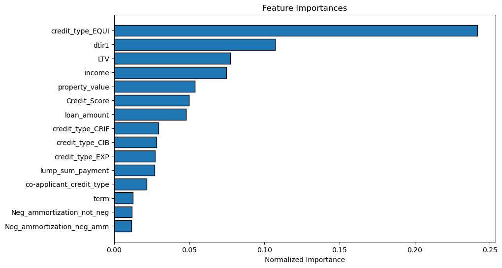

```python
# Train a Random Forest classifier on the imputed training data
clf_RF.fit(X_train_imputed, target_train)

pred_analysis_randomforest(clf_RF, X_test_imputed, target_train, target_test, list(new_X_train.columns))
```

### 缺失值处理方法：平均和丢弃结合

```
[Parallel(n_jobs=-1)]: Using backend ThreadingBackend with 8 concurrent workers.
[Parallel(n_jobs=-1)]: Done  34 tasks      | elapsed:    1.5s
[Parallel(n_jobs=-1)]: Done 184 tasks      | elapsed:    7.2s
[Parallel(n_jobs=-1)]: Done 200 out of 200 | elapsed:    7.8s finished
[Parallel(n_jobs=8)]: Using backend ThreadingBackend with 8 concurrent workers.
[Parallel(n_jobs=8)]: Done  34 tasks      | elapsed:    0.0s
[Parallel(n_jobs=8)]: Done 184 tasks      | elapsed:    0.3s
[Parallel(n_jobs=8)]: Done 200 out of 200 | elapsed:    0.3s finished
```

```
Accuracy: 0.890, Precision: 0.927, Recall: 0.610, ROC AUC: 0.797
```

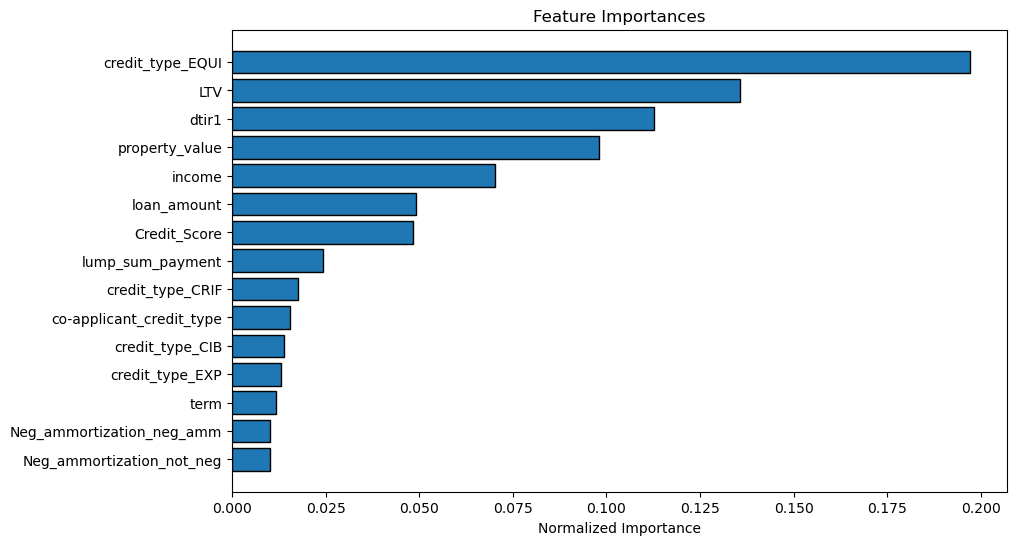

```python
#fill the nan values in the fill_list with corresponding mean values
fill_list = ["dtir1", "property_value", "LTV"]

X_train_imputed_mean = X_train.copy()
X_test_imputed_mean = X_test.copy()
for col in fill_list:
    X_train_imputed_mean[col].fillna(X_train_imputed_mean[col].mean(), inplace = True)
    X_test_imputed_mean[col].fillna(X_test_imputed_mean[col].mean(), inplace = True)

# drop the rest of the nan values
X_train_imputed_mean = X_train_imputed_mean.dropna(axis = 0, how = "any")
X_test_imputed_mean = X_test_imputed_mean.dropna(axis = 0, how = "any")

# Drop the target column from the training set and save it as a separate variable
target_train_mean = X_train_imputed_mean.pop("Status")
target_test_mean = X_test_imputed_mean.pop("Status")

# Train a Random Forest classifier on the imputed training data
clf_RF.fit(X_train_imputed_mean, target_train_mean)

pred_analysis_randomforest(clf_RF, X_test_imputed_mean, target_train_mean, target_test_mean,list(X_train_imputed_mean.columns))
```

### 缺失值处理方法：全部丢弃

```
[Parallel(n_jobs=-1)]: Using backend ThreadingBackend with 8 concurrent workers.
[Parallel(n_jobs=-1)]: Done  34 tasks      | elapsed:    1.3s
[Parallel(n_jobs=-1)]: Done 184 tasks      | elapsed:    6.7s
[Parallel(n_jobs=-1)]: Done 200 out of 200 | elapsed:    7.1s finished
[Parallel(n_jobs=8)]: Using backend ThreadingBackend with 8 concurrent workers.
[Parallel(n_jobs=8)]: Done  34 tasks      | elapsed:    0.0s
[Parallel(n_jobs=8)]: Done 184 tasks      | elapsed:    0.2s
[Parallel(n_jobs=8)]: Done 200 out of 200 | elapsed:    0.2s finished
```

```
Accuracy: 0.878, Precision: 0.788, Recall: 0.331, ROC AUC: 0.657
```

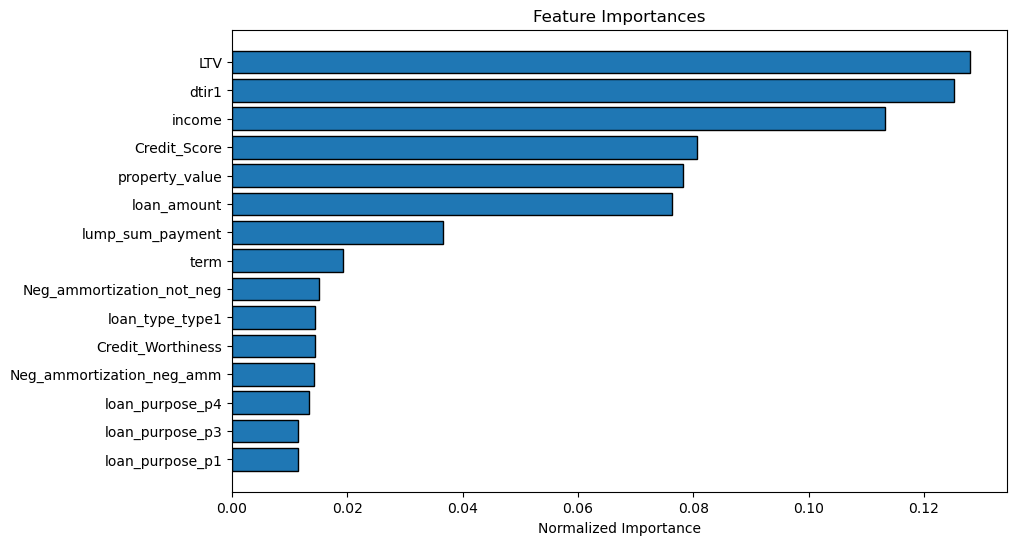

```python
X_train_imputed_drop = X_train.copy().dropna()
X_test_imputed_drop = X_test.copy().dropna()

# Drop the target column from the training set and save it as a separate variable
target_train_drop = X_train_imputed_drop.pop("Status")
target_test_drop = X_test_imputed_drop.pop("Status")

# Train a Random Forest classifier on the imputed training data
clf_RF.fit(X_train_imputed_drop, target_train_drop)

pred_analysis_randomforest(clf_RF, X_test_imputed_drop, target_train_drop, target_test_drop,list(X_train_imputed_drop.columns))
```

## 2.逻辑回归模型

```python
def pred_analysis_logit(clf, X_test_imputed, target_train, target_test, features):
    # Make predictions on the modified test data
    preds = clf.predict(X_test_imputed)

    # Evaluate the model using accuracy, precision, and ROC AUC score
    evaluation(target_test, preds)

    # importance analysis
    feature_importance_values = abs(clf.coef_[0])
    feature_importances = pd.DataFrame({'feature': features, 'importance': feature_importance_values})
    # plot the importance analysis
    feature_importances_sorted = plot_feature_importances(feature_importances)
```

- 由于逻辑回归对线性相关性有较高的敏感度，所以我们排除解释变量相关性大于0.8的变量进行模型搭建

```python
del_var = [i[1] for i in top_corr_pairs.index[top_corr_pairs>0.8]]#选择相关性大于0.8的变量删除
delcolindex = [new_X_train.columns.get_loc(i) for i in del_var]

# iterative imputer
trimed_X_train_imputed = np.delete(X_train_imputed.copy(), delcolindex, axis=1)
trimed_X_test_imputed = np.delete(X_test_imputed.copy(), delcolindex, axis=1)

# mean and drop
trimed_X_train_imputed_mean = X_train_imputed_mean.copy().drop(del_var, axis=1)
trimed_X_test_imputed_mean = X_test_imputed_mean.copy().drop(del_var, axis=1)

# drop
trimed_X_train_imputed_drop = X_train_imputed_drop.copy().drop(del_var, axis=1)
trimed_X_test_imputed_drop = X_test_imputed_drop.copy().drop(del_var, axis=1)
```

### 模型调参

```python
# 初始化逻辑回归模型
clf_LG_init = LogisticRegression(random_state=42)

# 定义参数网格
param_grid_LG = {'C': [0.001, 0.01, 0.1, 1, 10, 20, 30, 50],
                 'penalty': ['l1', 'l2', 'elasticnet'],
                 'solver': ['liblinear', 'lbfgs']}

# 初始化GridSearchCV
grid_search_LG = GridSearchCV(estimator=clf_LG_init, param_grid=param_grid_LG, cv=5, scoring='recall')

# 执行参数搜索
grid_search_LG.fit(trimed_X_train_imputed, target_train)

# 输出最佳参数和最佳得分
best_params_LG = grid_search_LG.best_params_
best_score_LG = grid_search_LG.best_score_
print("Best Parameters:", best_params_LG)
print("Best Score:", best_score_LG)

# 得到最优参数模型
clf_LG = grid_search_LG.best_estimator_
```

```
Best Parameters: {'C': 50, 'penalty': 'l1', 'solver': 'liblinear'}
Best Score: 0.484078440975191
```

- 调参结果： {'C': 50, 'penalty': 'l1', 'solver': 'liblinear'}

### 缺失值处理方法：迭代法

```
Accuracy: 0.867, Precision: 0.940, Recall: 0.484, ROC AUC: 0.737
```

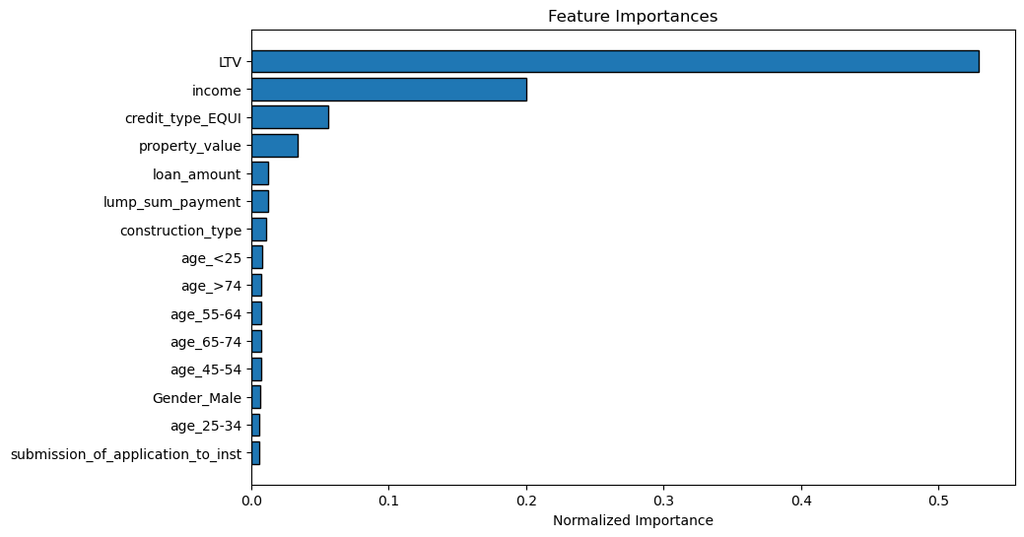

```python
# Train a logistic regression model on the modified training data
clf_LG.fit(trimed_X_train_imputed, target_train)

pred_analysis_logit(clf_LG, trimed_X_test_imputed, target_train, target_test, list(trimed_X_train_imputed_mean.columns))
```

### 缺失值处理方法：平均和丢弃

```
Accuracy: 0.866, Precision: 0.935, Recall: 0.501, ROC AUC: 0.745
```

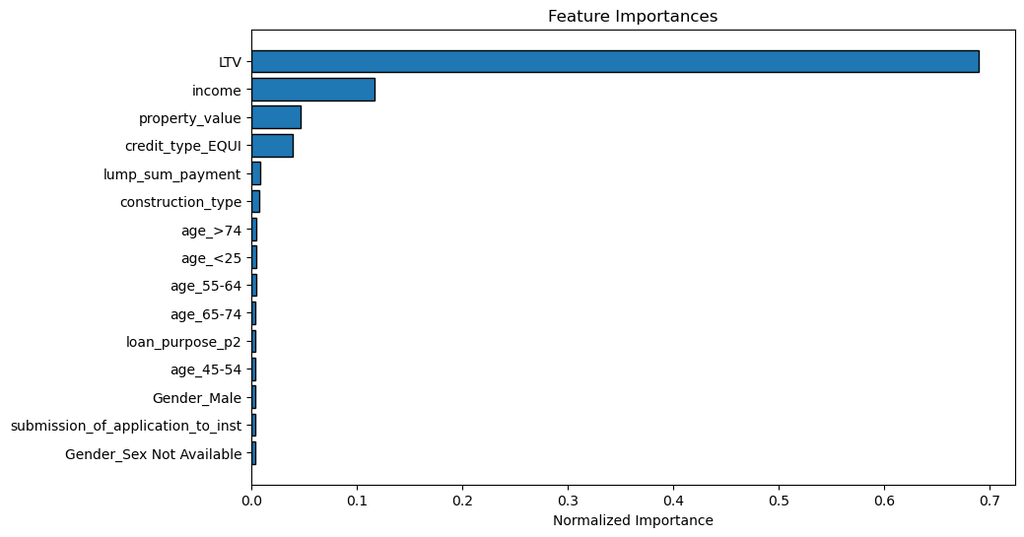

```python
# Train a logistic regression model on the modified training data
clf_LG.fit(trimed_X_train_imputed_mean, target_train_mean)

pred_analysis_logit(clf_LG, trimed_X_test_imputed_mean, target_train_mean, target_test_mean, list(trimed_X_train_imputed_mean.columns))
```

### 缺失值处理方法：全部丢弃

```
Accuracy: 0.850, Precision: 0.678, Recall: 0.128, ROC AUC: 0.558
```

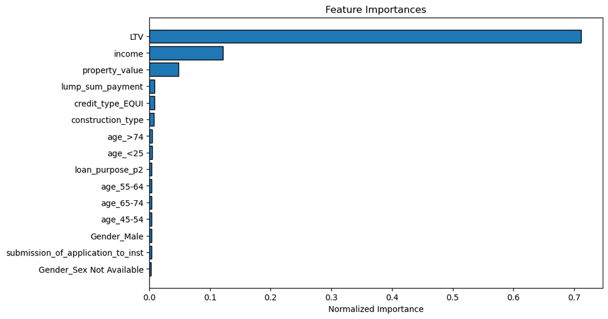

```python
# Train a logistic regression model on the modified training data
clf_LG.fit(trimed_X_train_imputed_drop, target_train_drop)

pred_analysis_logit(clf_LG, trimed_X_test_imputed_drop, target_train_drop, target_test_drop, list(trimed_X_train_imputed_drop.columns))
```

## 3、梯度提升决策树模型 (LGBM)

### 模型调参

```python
# 模型初始化
clf_LGBM_init = LGBMClassifier(min_data_in_leaf= 50,
                               random_state=42,
                               verbose = -1)

# 定义参数网格
param_grid_LGBM = {
    'learning_rate': [0.1, 0.2, 0.5, 0.7],
    'n_estimators': [100, 200, 500],
    'max_depth': [5, 7, 9, 12],
    'num_leaves': [50, 100, 200],
}

# 初始化GridSearchCV
grid_search_LGBM = GridSearchCV(estimator=clf_LGBM_init, param_grid=param_grid_LGBM, cv=3, scoring='recall')

# 在训练集上执行网格搜索
grid_search_LGBM.fit(X_train_imputed, target_train)

# 输出最佳参数和最佳得分
print("Best Parameters: ", grid_search_LGBM.best_params_)
print("Best Score: ", grid_search_LGBM.best_score_)

#得到最佳模型
clf_LGBM = grid_search_LGBM.best_estimator_
```

```
Best Parameters:  {'learning_rate': 0.7, 'max_depth': 5, 'n_estimators': 500, 'num_leaves': 50}
Best Score:  0.6496722927904414
```

- 调参结果: {'learning_rate': 0.7, 'max_depth': 5, 'n_estimators': 500, 'num_leaves': 50}

```python
def pred_analysis_LGBM(clf, X_test_imputed, target_train, target_test, features):
    # Make predictions on the imputed test data
    preds = clf.predict(X_test_imputed)

    # Evaluate the model using accuracy, precision, and ROC AUC score
    evaluation(target_test, preds)

    # importance analysis
    feature_importance_values = clf.feature_importances_
    feature_importances = pd.DataFrame({'feature': features, 'importance': feature_importance_values})
    # plot the importance analysis
    feature_importances_sorted = plot_feature_importances(feature_importances)
```

### 缺失值处理方法：迭代法

```
Accuracy: 0.879, Precision: 0.810, Recall: 0.658, ROC AUC: 0.804
```

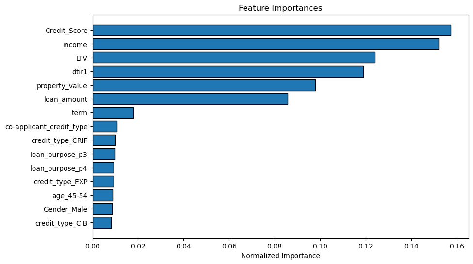

```python
# Train a Random Forest classifier on the imputed training data
clf_LGBM.fit(X_train_imputed, target_train)

pred_analysis_LGBM(clf_LGBM, X_test_imputed, target_train, target_test, list(new_X_train.columns))
```

### 缺失值处理方法：平均和丢弃

```
Accuracy: 0.880, Precision: 0.821, Recall: 0.666, ROC AUC: 0.809
```

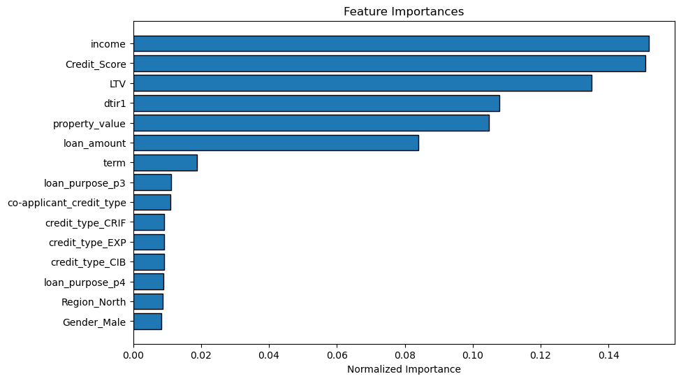

```python
# Train a Random Forest classifier on the imputed training data
clf_LGBM.fit(X_train_imputed_mean, target_train_mean)

pred_analysis_LGBM(clf_LGBM, X_test_imputed_mean, target_train_mean, target_test_mean, list(X_train_imputed_mean.columns))
```

### 缺失值处理方法：全部丢弃

```
Accuracy: 0.864, Precision: 0.612, Recall: 0.417, ROC AUC: 0.683
```

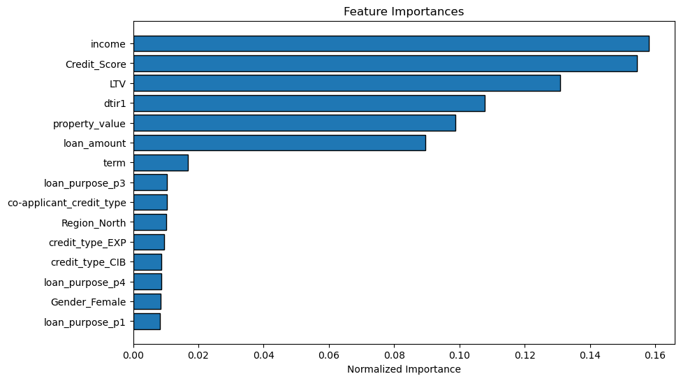

```python
# Train a Random Forest classifier on the imputed training data
clf_LGBM.fit(X_train_imputed_drop, target_train_drop)

pred_analysis_LGBM(clf_LGBM, X_test_imputed_drop, target_train_drop, target_test_drop,list(X_train_imputed_mean.columns))
```

## 4. 模型结果比较

```python
res_index = pd.MultiIndex.from_tuples([("Random Forest", "Iterative"), ("Random Forest", "Mean and Drop"), ("Random Forest", "Drop"),
        ("Logistic Regression", "Iterative"), ("Logistic Regression", "Mean and Drop"), ("Logistic Regression", "Drop"),
        ("LGBM", "Iterative"), ("LGBM", "Mean and Drop"), ("LGBM", "Drop")],
                                     names = ["Model", "Imputer"])
res_columns = ["Accuracy", "Precision", "Recall", "ROC AUC", "TOP 3 features"]
res_data = [[0.890, 0.930, 0.593, 0.789, ["credit_type_EQUI", "dtir1", "LTV"]],
         [0.890, 0.927, 0.610, 0.797, ["credit_type_EQUI", "LTV", "dtir1"]],
         [0.878, 0.788, 0.331, 0.657, ["LTV", "dtir1", "income"]],
         [0.867, 0.940, 0.484, 0.737, ["LTV", "income", "credit_type_EQUI"]],
         [0.866, 0.935, 0.501, 0.745, ["LTV", "income", "property_value"]],
         [0.850, 0.678, 0.128, 0.558, ["LTV", "income", "property_value"]],
         [0.879, 0.810, 0.658, 0.804, ["Credit_Score", "income", "LTV"]],
         [0.880, 0.821, 0.666, 0.809, ["income", "Credit_Score", "LTV"]],
         [0.864, 0.612, 0.417, 0.683, ["income", "Credit_Score", "LTV"]]
       ]
res_df = pd.DataFrame(data = res_data, index = res_index, columns = res_columns)
res_df_sorted = res_df.sort_values(by = "Recall", ascending = False)
res_df_sorted
```

| Model | Imputer | Accuracy | Precision | Recall | ROC AUC | TOP 3 features |
| --- | --- | --- | --- | --- | --- | --- |
| LGBM | Mean and Drop | 0.880 | 0.821 | 0.666 | 0.809 | [income, Credit_Score, LTV] |
|  | Iterative | 0.879 | 0.810 | 0.658 | 0.804 | [Credit_Score, income, LTV] |
| Random Forest | Mean and Drop | 0.890 | 0.927 | 0.610 | 0.797 | [credit_type_EQUI, LTV, dtir1] |
|  | Iterative | 0.890 | 0.930 | 0.593 | 0.789 | [credit_type_EQUI, dtir1, LTV] |
| Logistic Regression | Mean and Drop | 0.866 | 0.935 | 0.501 | 0.745 | [LTV, income, property_value] |
|  | Iterative | 0.867 | 0.940 | 0.484 | 0.737 | [LTV, income, credit_type_EQUI] |
| LGBM | Drop | 0.864 | 0.612 | 0.417 | 0.683 | [income, Credit_Score, LTV] |
| Random Forest | Drop | 0.878 | 0.788 | 0.331 | 0.657 | [LTV, dtir1, income] |
| Logistic Regression | Drop | 0.850 | 0.678 | 0.128 | 0.558 | [LTV, income, property_value] |

# 五、结果分析

结论：

- 去最优模型(优先取Recall最高模型)：LGBM， imputer为Mean and Drop
- 综合选取最重要的三个解释变量：LTV，income，和Credit_Score

后续和改进：

- 碍于计算机算力和项目时间限制，超参tunning在逻辑上存在不严谨的地方，后续可以改进：cv tunning 和 imputer比较等
- 对于部分解释变量的业务逻辑了解不全面，例如dtir1和loan_type等，需要更多解释信息
- outliers是否需要选择性忽略存在疑惑，本次训练出于业务层面考虑选择保留，后续需要进一步确认合理性
- 归一化本次只使用了MinMaxScalar，并未对多种归一化手法进行对比，后续可以增加相关比较
- 模型和imputer的范围有限，选择根据理论上较好的原则进行，后续可以扩大测试和比较的范围
- Interest_rate_spread，Upfront_charges，和rate_of_interest对结果变量Status有非常强的相关性，会导致模型的极端化。本次训练选择丢弃这些解释变量，但并未能对其在业务层面的逻辑做出合理解释，后续需要进一步确认丢弃动作的合理性